# Lab 2: Classification

## Modeling and Evaluation

```python
def rmse(y_actual, y_predicted):
    return np.sqrt(mean_squared_error(y_actual, y_predicted))

#Function for Mean Absolute Percentage Error (MAPE)
#Adapted from - https://stackoverflow.com/questions/42250958/how-to-optimize-mape-code-in-python
def mape(y_actual, y_predicted):
    mask = y_actual != 0
    return (np.fabs(y_actual - y_predicted)/y_actual)[mask].mean() * 100

#Create scorers for rmse and mape functions
mae_scorer = make_scorer(score_func=mean_absolute_error, greater_is_better=False)
rmse_scorer = make_scorer(score_func=rmse, greater_is_better=False)
mape_scorer = make_scorer(score_func=mape, greater_is_better=False)

#Make scorer array to pass into cross_validate() function for producing mutiple scores for each cv fold.
errorScoring = {'MAE':  mae_scorer,
                'RMSE': rmse_scorer,
                'MAPE': mape_scorer
               }
```

```python
def EvaluateRegressionEstimator(regEstimator, x, y, cv):

    scores = cross_validate(regEstimator, x, y, scoring=errorScoring, cv=cv, return_train_score=True)

    #cross val score sign-flips the outputs of MAE
    # https://github.com/scikit-learn/scikit-learn/issues/2439
    scores['test_MAE'] = scores['test_MAE'] * -1
    scores['test_MAPE'] = scores['test_MAPE'] * -1
    scores['test_RMSE'] = scores['test_RMSE'] * -1

    #print mean MAE for all folds
    maeAvg = scores['test_MAE'].mean()
    print_str = "The average MAE for all cv folds is: \t\t\t {maeAvg:.5}"
    print(print_str.format(maeAvg=maeAvg))

    #print mean test_MAPE for all folds
    scores['test_MAPE'] = scores['test_MAPE']
    mape_avg = scores['test_MAPE'].mean()
    print_str = "The average MAE percentage (MAPE) for all cv folds is: \t {mape_avg:.5}"
    print(print_str.format(mape_avg=mape_avg))

    #print mean MAE for all folds
    RMSEavg = scores['test_RMSE'].mean()
    print_str = "The average RMSE for all cv folds is: \t\t\t {RMSEavg:.5}"
    print(print_str.format(RMSEavg=RMSEavg))
    print('*********************************************************')

    print('Cross Validation Fold Mean Error Scores')
    scoresResults = pd.DataFrame()
    scoresResults['MAE'] = scores['test_MAE']
    scoresResults['MAPE'] = scores['test_MAPE']
    scoresResults['RMSE'] = scores['test_RMSE']
    return scoresResults
```

This function caps the predicted values for our regression at 150. The max value in our dataset is 120.

```python
#Make new estimator compatible for use with GridSearchCV() and cross_validate()
# -  Cap predict function for LinearRegression between 0 and 150

class CappedLinearRegression(LinearRegression):

    def predict(self, x):
        return np.clip(super(CappedLinearRegression, self).predict(x), 0, 150)
```

## Regression - Parameter Tuning Using Grid Search

```python
#Create a Linear Regression object and perform a grid search to find the best parameters
linreg = CappedLinearRegression()
parameters = {'normalize':(True,False), 'fit_intercept':(True,False)}

#Create a grid search object using the
regGridSearch = GridSearchCV(estimator=linreg
                   , verbose=1 # low verbosity
                   , param_grid=parameters
                   , cv=cv # KFolds = 10
                   , scoring=mae_scorer)

#Perform hyperparameter search to find the best combination of parameters for our data
regGridSearch.fit(x, y)
```

```
Fitting 10 folds for each of 4 candidates, totalling 40 fits
```

```
[Parallel(n_jobs=1)]: Using backend SequentialBackend with 1 concurrent workers.
[Parallel(n_jobs=1)]: Done  40 out of  40 | elapsed:    0.1s finished
```

```
GridSearchCV(cv=ShuffleSplit(n_splits=10, random_state=99, test_size=0.1, train_size=None),
             estimator=CappedLinearRegression(),
             param_grid={'fit_intercept': (True, False),
                         'normalize': (True, False)},
             scoring=make_scorer(mean_absolute_error, greater_is_better=False),
             verbose=1)
```

```python
#Print the parameterization of the best estimator
regGridSearch.best_estimator_
```

```
CappedLinearRegression(normalize=True)
```

### Regression - Baseline Analysis

```python
#Create CappedLinearRegression predictions between 0 and $150 using the best parameters for our Linear Regression object
regEstimator = regGridSearch.best_estimator_

#Evaluate the regression estimator above using our pre-defined cross validation and scoring metrics.
EvaluateRegressionEstimator(regEstimator, x, y, cv)
```

```
The average MAE for all cv folds is: 			 0.78372
The average MAE percentage (MAPE) for all cv folds is: 	 1.3791
The average RMSE for all cv folds is: 			 1.0249
Cross Validation Fold Mean Error Scores
```

|  | MAE | MAPE | RMSE |
| --- | --- | --- | --- |
| 0 | 0.839909 | 1.426827 | 1.093134 |
| 1 | 0.755612 | 1.342694 | 1.008420 |
| 2 | 0.777725 | 1.342619 | 1.027155 |
| 3 | 0.774009 | 1.339207 | 1.027833 |
| 4 | 0.828538 | 1.428436 | 1.049826 |
| 5 | 0.808171 | 1.500566 | 1.054604 |
| 6 | 0.738376 | 1.304682 | 0.971843 |
| 7 | 0.760341 | 1.312848 | 1.002413 |
| 8 | 0.744313 | 1.337621 | 0.973134 |
| 9 | 0.810216 | 1.455957 | 1.040891 |

```python
regEstimator.fit(x, y)
yhat = regEstimator.predict(x)
print("Yhat Max: ", yhat.max())
print("Yhat Mean: ", yhat.mean())
```

```
Yhat Max:  115.0390625
Yhat Mean:  64.76156816830542
```

### Regression - Support Vector Regression

```python
#Create a Linear regression object and perform a grid search to find the best parameters
reg = SVR()

#Set up SVR parameters to test
costs = [0.001, 0.1]
defGamma = 1 / x.shape[1]  #This is the default value for the gamma parameter
gammas = [defGamma, 0.1]
kernels = ['rbf','linear']
parameters = {'C': costs, 'gamma' : gammas, 'kernel': kernels}

#Create a grid search object using the parameters above
from sklearn.model_selection import GridSearchCV
regGridSearch = GridSearchCV(estimator=reg
                   , n_jobs=-1 # jobs to run in parallel
                   , verbose=1 # low verbosity
                   , param_grid=parameters
                   , cv=cv # KFolds = 10
                   , scoring=mae_scorer)

#Perform hyperparameter search to find the best combination of parameters for our data
regGridSearch.fit(x,y)
```

```
Fitting 10 folds for each of 8 candidates, totalling 80 fits
```

```
[Parallel(n_jobs=-1)]: Using backend LokyBackend with 16 concurrent workers.
[Parallel(n_jobs=-1)]: Done  18 tasks      | elapsed:    4.8s
[Parallel(n_jobs=-1)]: Done  80 out of  80 | elapsed:   19.6s finished
```

```
GridSearchCV(cv=ShuffleSplit(n_splits=10, random_state=99, test_size=0.1, train_size=None),
             estimator=SVR(), n_jobs=-1,
             param_grid={'C': [0.001, 0.1],
                         'gamma': [0.038461538461538464, 0.1],
                         'kernel': ['rbf', 'linear']},
             scoring=make_scorer(mean_absolute_error, greater_is_better=False),
             verbose=1)
```

```python
regGridSearch.best_estimator_
```

```
SVR(C=0.1, gamma=0.038461538461538464, kernel='linear')
```

```python
#Create a regression estimator with best parameters for cross validation
regEstimator = SVR(C=0.1, gamma=0.038461538461538464, kernel='linear')

#Evaluate the regression estimator above using our pre-defined cross validation and scoring metrics.
EvaluateRegressionEstimator(regEstimator, x, y, cv)
```

```
The average MAE for all cv folds is: 			 0.79774
The average MAE percentage (MAPE) for all cv folds is: 	 1.4183
The average RMSE for all cv folds is: 			 1.0397
Cross Validation Fold Mean Error Scores
```

|  | MAE | MAPE | RMSE |
| --- | --- | --- | --- |
| 0 | 0.860768 | 1.495349 | 1.109914 |
| 1 | 0.767610 | 1.375668 | 1.022914 |
| 2 | 0.794099 | 1.389214 | 1.041448 |
| 3 | 0.798834 | 1.397012 | 1.052575 |
| 4 | 0.840741 | 1.454169 | 1.065995 |
| 5 | 0.828073 | 1.540756 | 1.079268 |
| 6 | 0.748456 | 1.336251 | 0.979939 |
| 7 | 0.772870 | 1.355621 | 1.021259 |
| 8 | 0.758301 | 1.381358 | 0.979306 |
| 9 | 0.807685 | 1.457635 | 1.044793 |

```python
regEstimator.fit(x, y)
yhat = regEstimator.predict(x)
print("Yhat Max: ", yhat.max())
print("Yhat Mean: ", yhat.mean())
```

```
Yhat Max:  115.07104108865217
Yhat Mean:  64.72797731824387
```

After performing support vector regression we can see that our error metrics are very similar. This model also predicts a similar monthly charge to the original regression model.

### Regression - Elastic Net Regression

```python
#Create a regression object and perform a grid search to find the best parameters
reg = ElasticNet(fit_intercept=True, normalize=True, precompute=True, copy_X=True
          , max_iter=10000, tol=0.0001, random_state=0)

#Test parameters
l1_ratio = [0.001, 0.01, 0.1, 0.5, 0.75, 1]
alpha = [0.001, 0.1, 1, 10]
selection = ['cyclic','random']
warm_start = [True, False]
parameters = {'l1_ratio': l1_ratio, 'alpha': alpha, 'selection': selection, 'warm_start': warm_start}

#Create a grid search object using the parameters above
regGridSearch = GridSearchCV(estimator=reg
                   , n_jobs=-1 # jobs to run in parallel
                   , verbose=1 # low verbosity
                   , param_grid=parameters
                   , cv=cv # KFolds = 10
                   , scoring=mae_scorer)

#Perform hyperparameter search to find the best combination of parameters for our data
regGridSearch.fit(x, y)
```

```
Fitting 10 folds for each of 96 candidates, totalling 960 fits
```

```
[Parallel(n_jobs=-1)]: Using backend LokyBackend with 16 concurrent workers.
[Parallel(n_jobs=-1)]: Done  18 tasks      | elapsed:    0.0s
[Parallel(n_jobs=-1)]: Done 760 tasks      | elapsed:    0.8s
[Parallel(n_jobs=-1)]: Done 960 out of 960 | elapsed:    1.1s finished
```

```
GridSearchCV(cv=ShuffleSplit(n_splits=10, random_state=99, test_size=0.1, train_size=None),
             estimator=ElasticNet(max_iter=10000, normalize=True,
                                  precompute=True, random_state=0),
             n_jobs=-1,
             param_grid={'alpha': [0.001, 0.1, 1, 10],
                         'l1_ratio': [0.001, 0.01, 0.1, 0.5, 0.75, 1],
                         'selection': ['cyclic', 'random'],
                         'warm_start': [True, False]},
             scoring=make_scorer(mean_absolute_error, greater_is_better=False),
             verbose=1)
```

```python
regGridSearch.best_estimator_
```

```
ElasticNet(alpha=0.001, l1_ratio=1, max_iter=10000, normalize=True,
           precompute=True, random_state=0, selection='random',
           warm_start=True)
```

```python
#Create a regression estimator with best parameters for cross validation
regEstimator = ElasticNet(alpha=0.001, l1_ratio=1, max_iter=10000, normalize=True,
           precompute=True, random_state=0, warm_start=True)

#Evaluate the regression estimator above using our pre-defined cross validation and scoring metrics.
EvaluateRegressionEstimator(regEstimator, x, y, cv)
```

```
The average MAE for all cv folds is: 			 0.79105
The average MAE percentage (MAPE) for all cv folds is: 	 1.4071
The average RMSE for all cv folds is: 			 1.0337
Cross Validation Fold Mean Error Scores
```

|  | MAE | MAPE | RMSE |
| --- | --- | --- | --- |
| 0 | 0.851829 | 1.478485 | 1.104005 |
| 1 | 0.752244 | 1.350869 | 1.005504 |
| 2 | 0.789163 | 1.382470 | 1.037141 |
| 3 | 0.788520 | 1.377816 | 1.042274 |
| 4 | 0.834773 | 1.447606 | 1.057443 |
| 5 | 0.811523 | 1.515551 | 1.062978 |
| 6 | 0.749670 | 1.343508 | 0.978684 |
| 7 | 0.765593 | 1.338445 | 1.017773 |
| 8 | 0.752086 | 1.363528 | 0.982345 |
| 9 | 0.815091 | 1.472859 | 1.048824 |

```python
regEstimator.fit(x, y)
yhat = regEstimator.predict(x)
print("Yhat Max: ", yhat.max())
print("Yhat Mean: ", yhat.mean())
```

```
Yhat Max:  114.61039542315451
Yhat Mean:  64.76169246059918
```

### Regression - Random Forest Regressor

```python
#Create a Linear Regression object and perform a grid search to find the best parameters
linreg = RandomForestRegressor()
parameters = { 'min_samples_split':[2,3,4,5]
              ,'n_estimators' : [500]
              ,'min_samples_leaf': [10, 25, 50]
              ,'criterion': ['mae']
              ,'n_jobs':[16]
              ,'random_state': [0]
             }

#Create a grid search object using the
regGridSearch = GridSearchCV(estimator=linreg
                   , n_jobs=-1
                   , verbose=1 # low verbosity
                   , param_grid=parameters
                   , cv=cv # KFolds = 10
                   , scoring=mae_scorer)

#Perform hyperparameter search to find the best combination of parameters for our data
regGridSearch.fit(x, y)
```

```
[Parallel(n_jobs=-1)]: Using backend LokyBackend with 16 concurrent workers.
```

```
Fitting 10 folds for each of 12 candidates, totalling 120 fits
```

```
[Parallel(n_jobs=-1)]: Done  18 tasks      | elapsed: 12.2min
[Parallel(n_jobs=-1)]: Done 120 out of 120 | elapsed: 45.1min finished
```

```
GridSearchCV(cv=ShuffleSplit(n_splits=10, random_state=99, test_size=0.1, train_size=None),
             estimator=RandomForestRegressor(), n_jobs=-1,
             param_grid={'criterion': ['mae'], 'min_samples_leaf': [10, 25, 50],
                         'min_samples_split': [2, 3, 4, 5],
                         'n_estimators': [500], 'n_jobs': [16],
                         'random_state': [0]},
             scoring=make_scorer(mean_absolute_error, greater_is_better=False),
             verbose=1)
```

```python
regGridSearch.best_estimator_
```

```
RandomForestRegressor(criterion='mae', min_samples_leaf=10, n_estimators=500,
                      n_jobs=16, random_state=0)
```

```python
regEstimator = RandomForestRegressor(criterion='mae', min_samples_leaf=10, n_estimators=500,
                      n_jobs=8, random_state=0)

EvaluateRegressionEstimator(regEstimator, x, y, cv)
```

```
The average MAE for all cv folds is: 			 1.2724
The average MAE percentage (MAPE) for all cv folds is: 	 2.108
The average RMSE for all cv folds is: 			 1.8063
Cross Validation Fold Mean Error Scores
```

|  | MAE | MAPE | RMSE |
| --- | --- | --- | --- |
| 0 | 1.284502 | 2.146171 | 1.873800 |
| 1 | 1.263067 | 2.101242 | 1.780492 |
| 2 | 1.284040 | 2.093229 | 1.780594 |
| 3 | 1.236537 | 2.008507 | 1.774299 |
| 4 | 1.318612 | 2.161140 | 1.842569 |
| 5 | 1.298178 | 2.229133 | 1.857218 |
| 6 | 1.213825 | 2.002624 | 1.716505 |
| 7 | 1.297141 | 2.083903 | 1.826391 |
| 8 | 1.232318 | 2.100702 | 1.737549 |
| 9 | 1.296239 | 2.152852 | 1.873811 |

```python
regEstimator.fit(x, y)
yhat = regEstimator.predict(x)
print("Yhat Max: ", yhat.max())
print("Yhat Mean: ", yhat.mean())
```

```
Yhat Max:  115.65910000000014
Yhat Mean:  64.6499073406219
```

Despite being the most computationally expensive, the random trees regression method provides the worst error metrics.

### Regression - Check Feature Importance

```python
#Load the model's coefficient weights and feature names into a dataframe sorted by weights
weights = regEstimator.feature_importances_.ravel()
feature_names = x.columns.values
linreg_ft_imp_df = pd.DataFrame({'feature_names':feature_names, 'weights':weights, 'absolute_weights': np.abs(weights)})
linreg_ft_imp_df.sort_values(by='absolute_weights', inplace=True, ascending=False )
```

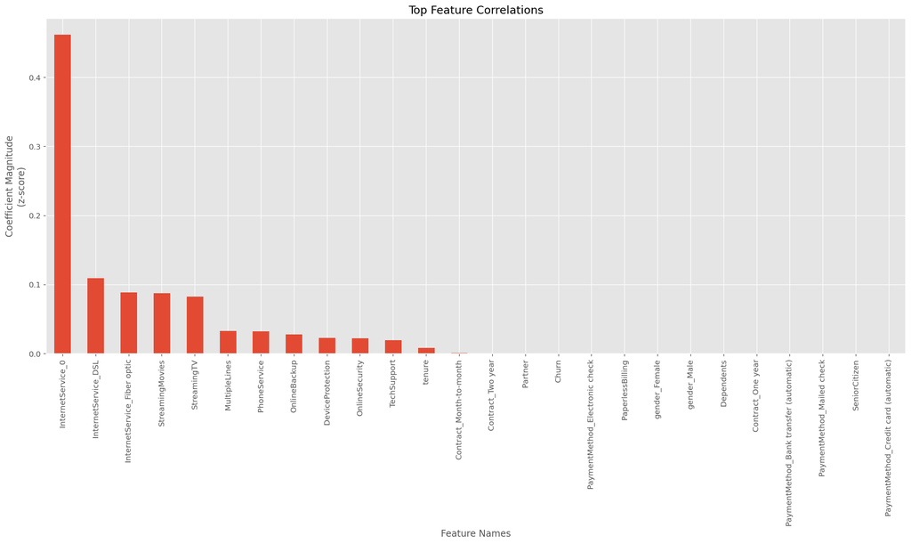

```python
# Examine categorical variables of interest
#Plot the model's feature importances
# REFERENCE:  Eric Larson, https://github.com/eclarson/DataMiningNotebooks
plt.style.use('ggplot')

wt_plt_df = linreg_ft_imp_df.head(75)

weights = pd.Series(wt_plt_df['weights'].values,index=wt_plt_df['feature_names'])
ax = weights.plot(kind='bar', figsize=(20,8))

ax.set_title("Top Feature Correlations")
ax.set_ylabel("Coefficient Magnitude\n(z-score)")
ax.set_xlabel("Feature Names")
plt.show()
```